# Visualizing Data

### Correlation between retweets and favorites

### Introduction

The WeRateDogs Twitter archive contains basic tweet data for all 5000+ of their tweets, but not everything. Hence the data was prepared by gathering from three different sources, assessing it in python and then cleaning the same

Twitter is a free social networking microblogging service that allows registered members to broadcast short posts called tweets. Twitter members can broadcast tweets and follow other users' tweets by using multiple platforms and devices. Tweets and replies to tweets can be sent by cell phone text message, desktop client or by posting at the Twitter.com website.

### Visualization 1: Correlation between favorites and retweets

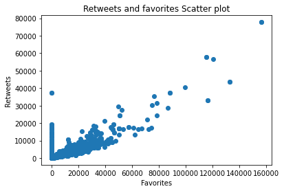

```python
plt.scatter(twitter_enhanced_df_clean['favorites'], twitter_enhanced_df_clean['retweets'])
plt.xlabel('Favorites')
plt.ylabel('Retweets')
plt.title('Retweets and favorites Scatter plot');
```

I was curious to know whether the popular tweets i.e. the tweets which have been liked the most, have they been retweeted more?

For this purpose, using python's Matplotlib package, I generated a scatter plot with 'Favorites' on the X-axis and 'Retweets' on the Y-axis.

From the results, it is very clear that 'retweets' and 'favorites' are highly correlated as the graph shows a Positive and a Strong Correlation

### Visualization 2: Which dog stage gets most tweets?

There are different dog stages in a life:

Doggo

- A doggo is a big pupper, usually older. Although, this label does not stop a doggo from behaving like a pupper.
- A pupper that appears to have its life in order. Probably understands taxes and what not

Pupper

- A small doggo but, usually younger. Can be equally if not more mature than some doggos.
- A doggo that is inexperienced and unprepared for any responsibilites associated with a doggo.

Puppo

- A transitional phase between a pupper and a doggo. Can be understood as a dog equivalent of a teenager.
- A dog with both pupper and doggo tendencies.

Floof

- A label given to dogs with seemingly excess fur. Comical amounts of fur on a dog will certainly earn this dog a generic name.

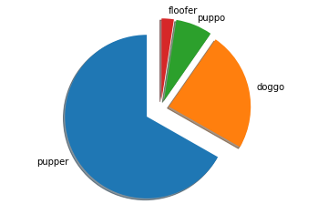

```python
life_stage_count = list(twitter_enhanced_df_clean[twitter_enhanced_df_clean['dog_life_stage'] != 'None']['dog_life_stage'].value_counts())[0:4]
life_stages = twitter_enhanced_df_clean[twitter_enhanced_df_clean['dog_life_stage'] != 'None']['dog_life_stage'].value_counts().index.tolist()[0:4]
explode = (0.2, 0.1, 0.1, 0.1)

figure1, axis1 = plt.subplots()
axis1.pie(life_stage_count, explode = explode, labels = life_stages, shadow = True, startangle = 90)
axis1.axis('equal');
```

Out of all the different stages, the most popular one as shown above is Pupper. This probably stems from the fact that Puppers are small and cute and hence people tend to love and write about them more.

Looks like people don't like fur much. Maybe they dont like cleaning, eh? Well, whatever maybe the reason but floofers find themselves as the least popular stage.

The old, loyal doggos find themselves in the second place. They would probably be proud of their sons and daughters.

The puppos are second to least popular

### Insight 1

```python
from IPython.display import HTML

HTML('''<script>
code_show=true;
function code_toggle() {
 if (code_show){
 $('div.input').hide();
 } else {
 $('div.input').show();
 }
 code_show = !code_show
}
$( document ).ready(code_toggle);
</script>
<form action="javascript:code_toggle()"><input type="submit" value="Click here to toggle on/off the raw code."></form>''')
```

```python
twitter_enhanced_df_clean=pd.read_csv('twitter_archive_master.csv')
```

```python
twitter_enhanced_df_clean['dog_gender'].value_counts()
```

```
male      611
female    212
Name: dog_gender, dtype: int64
```

See, there are so many commanlities between humans and dogs. Just like the human sex ratio even the dog sex ratio indicates more number of males than females. And that too an almost 3:1 ratio!!!!

(Note: A large number of dogs were unidentified)

### Insight 2

```python
grouped=twitter_enhanced_df_clean.groupby('prediction').mean()['rating_numerator']
grouped.sort_values(ascending=False)
```

```
prediction
soft-coated_wheaten_terrier    20.800000
West_Highland_white_terrier    15.214286
chow                           14.260870
Labrador_retriever             13.785714
borzoi                         13.545455
                                 ...
Scotch_terrier                  9.000000
Dandie_Dinmont                  9.000000
Walker_hound                    9.000000
Afghan_hound                    8.000000
Japanese_spaniel                5.000000
Name: rating_numerator, Length: 113, dtype: float64
```

The average rating has been vey high for white_terriers. The soft-coated wheaten terrier has received the most average rating while the west highland white terrier is second.

Unfortunately, Afghan hound and japaneses spaniel are the lowest rated breeds. But that doesn't mean that we should love them any less.

### Insight 3

```python
import matplotlib.pyplot as plt
%matplotlib inline
import seaborn as sns
```

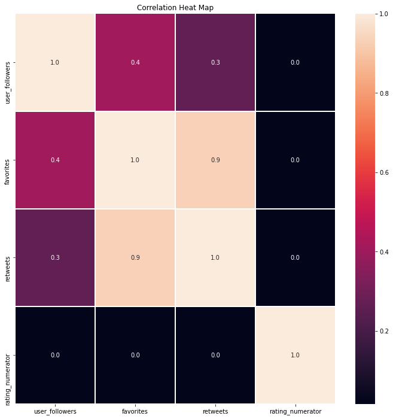

```python
f,ax = plt.subplots(figsize=(12, 12))
sns.heatmap(twitter_enhanced_df_clean[['user_followers','favorites','retweets',
               'rating_numerator']].corr(), annot=True, linewidths=.8, fmt= '.1f',ax=ax)
plt.title('Correlation Heat Map')
```

Except for favorites and retweets, every other pair has a weak correlation